# Data Visualization Analyses

Step 2: Here, I have loaded in the assignment_dataVis_dataset.csv file using the read.csv() function, and saved it to the variable ‘data’. I also used the View() function to take a look at the data in the file.

```r
setwd("/Users/shreiya/Downloads")
data<-read.csv("assignment_dataVis_dataset.csv",header=TRUE)

View(data)
```

Step 3: Next, I printed the summary stats for each of the 4 conditions in the dataset (note: first I had to save ‘condition’ as a factor, rather than character. This enabled me to have more efficient code).

Summary statistics I calculated include the means and the standard deviations for both the x and y values for each condition, as well as the size (n) of each condition.

SUMMARY STATISTICS:

```r
summary(data) #data summary
```

```
##   condition               x               y
##  Length:568         Min.   :19.29   Min.   : 2.949
##  Class :character   1st Qu.:41.67   1st Qu.:24.095
##  Mode  :character   Median :54.38   Median :46.354
##                     Mean   :54.27   Mean   :47.834
##                     3rd Qu.:65.02   3rd Qu.:69.199
##                     Max.   :98.21   Max.   :99.580
```

```r
data$condition <- as.factor(data$condition) #saving 'condition' as factor

summary(data) # n for each condition = 142
```

```
##        condition         x               y
##  condition_1:142   Min.   :19.29   Min.   : 2.949
##  condition_2:142   1st Qu.:41.67   1st Qu.:24.095
##  condition_3:142   Median :54.38   Median :46.354
##  condition_4:142   Mean   :54.27   Mean   :47.834
##                    3rd Qu.:65.02   3rd Qu.:69.199
##                    Max.   :98.21   Max.   :99.580
```

```r
#find the means for each condition in the data set (x):
(conditions_mean_x <- with(data, tapply(x, condition, mean)))
```

```
## condition_1 condition_2 condition_3 condition_4
##    54.26327    54.26873    54.26588    54.26734
```

```r
#find the means for each condition in the data set (y):
(conditions_mean_y <- with(data, tapply(y, condition, mean)))
```

```
## condition_1 condition_2 condition_3 condition_4
##    47.83225    47.83082    47.83150    47.83955
```

```r
#find the SD for each condition in the data set (x):
(conditions_sd_x <- with(data, tapply(x, condition, sd)))
```

```
## condition_1 condition_2 condition_3 condition_4
##    16.76514    16.76924    16.76885    16.76896
```

```r
#find the SD for each condition in the data set (y):
(conditions_sd_y <- with(data, tapply(y, condition, sd)))
```

```
## condition_1 condition_2 condition_3 condition_4
##    26.93540    26.93573    26.93861    26.93027
```

Step 4: Then, I visualized the data / results of each condition using scatter plots. I also found the Pearson’s correlation coefficient (r) for each of the conditions.

DATA VISUALIZATION:

```r
library(ggplot2)

df_condition_1 <- data[rownames(data)[c(1:142)],] #creating a data frame containing only the data points for condition 1
df_condition_2 <- data[rownames(data)[c(143:284)],] #creating a data frame containing only the data points for condition 2
df_condition_3 <- data[rownames(data)[c(285:426)],] #creating a data frame containing only the data points for condition 3
df_condition_4 <- data[rownames(data)[c(427:568)],] #creating a data frame containing only the data points for condition 4
```

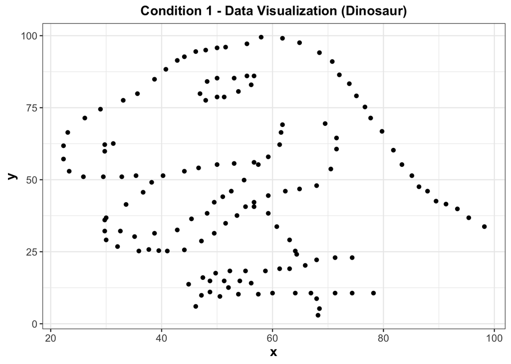

```r
#PLOT 1#
ggplot(df_condition_1, aes(x, y)) +
  geom_point() +
  theme_bw()+
  labs(
    title = "Condition 1 - Data Visualization (Dinosaur)",
    x = "x",
    y = "y",
    color="Gears"
    ) +
  theme(
    plot.title = element_text(face="bold", size="13", hjust=0.5),
    axis.text.y = element_text(size=10),
    axis.text.x = element_text(size=10),
    axis.title.x=element_text(face="bold", size=13),
    axis.title.y=element_text(face="bold", size=13))#visualization of the data for just condition 1; configuration of the data points for condition 1 resembles the shape of a dinosaur (t-rex) when visualized as a scatter plot
```

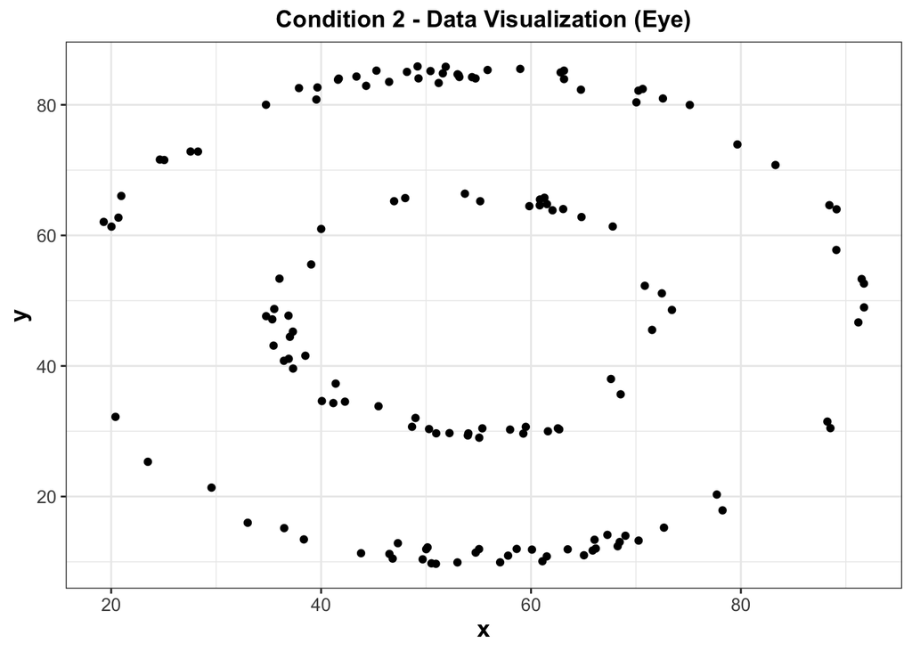

```r
#PLOT 2#
ggplot(df_condition_2, aes(x, y)) +
  geom_point()+
  theme_bw()+
  labs(
    title = "Condition 2 - Data Visualization (Eye)",
    x = "x",
    y = "y",
    color="Gears"
    ) +
  theme(
    plot.title = element_text(face="bold", size="13", hjust=0.5),
    axis.text.y = element_text(size=10),
    axis.text.x = element_text(size=10),
    axis.title.x=element_text(face="bold", size=13),
    axis.title.y=element_text(face="bold", size=13)) #visualization of the data for just condition 2; configuration of the data points for condition 2 resembles the shape of an eye when visualized as a scatter plot
```

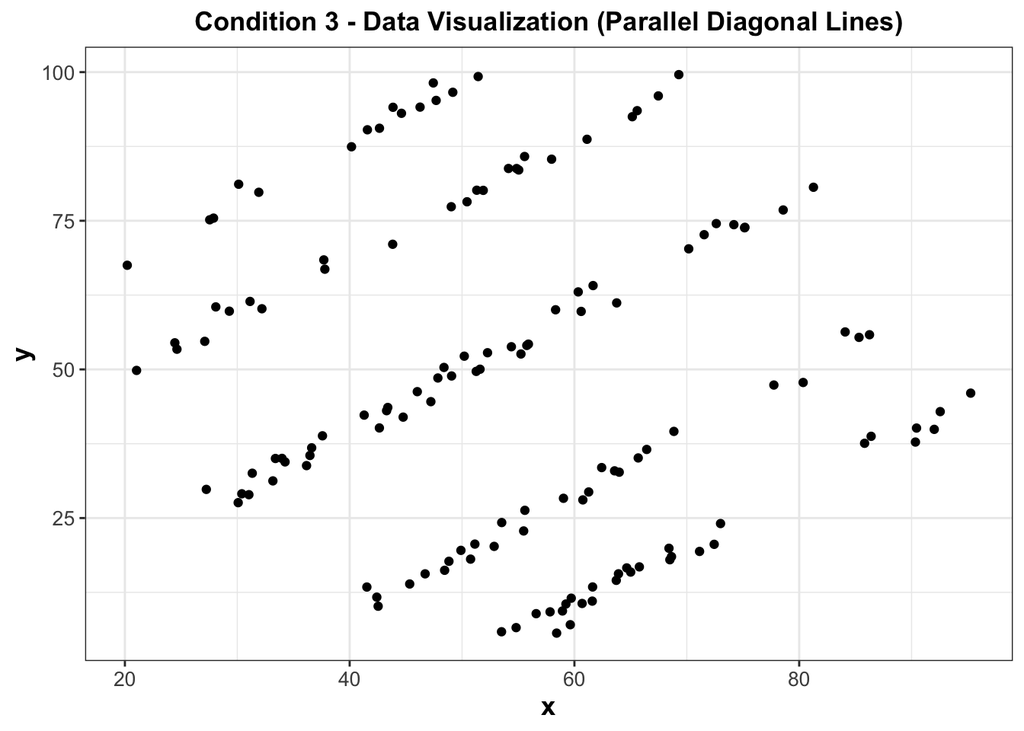

```r
#PLOT 3#
ggplot(df_condition_3, aes(x, y)) +
  geom_point()+
  theme_bw()+
  labs(
    title = "Condition 3 - Data Visualization (Parallel Diagonal Lines)",
    x = "x",
    y = "y",
    color="Gears"
    ) +
  theme(
    plot.title = element_text(face="bold", size="13", hjust=0.5),
    axis.text.y = element_text(size=10),
    axis.text.x = element_text(size=10),
    axis.title.x=element_text(face="bold", size=13),
    axis.title.y=element_text(face="bold", size=13)) #visualization of the data for just condition 3; configuration of the data points for condition 3 resemble five diagonal lines that are parallel when visualized as a scatter plot
```

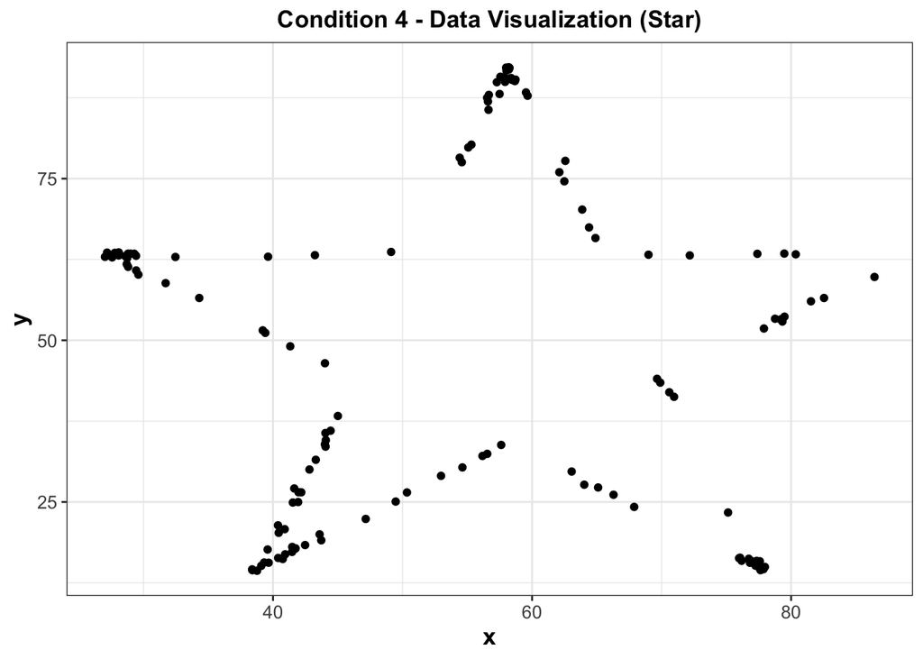

```r
#PLOT 4#
ggplot(df_condition_4, aes(x, y)) +
  geom_point()+
  theme_bw()+
  labs(
    title = "Condition 4 - Data Visualization (Star)",
    x = "x",
    y = "y",
    color="Gears"
    ) +
  theme(
    plot.title = element_text(face="bold", size="13", hjust=0.5),
    axis.text.y = element_text(size=10),
    axis.text.x = element_text(size=10),
    axis.title.x=element_text(face="bold", size=13),
    axis.title.y=element_text(face="bold", size=13)) #visualization of the data for just condition 4 ; configuration of the data points for condition 4 resemble the shape of a star when visualized as a scatter plot
```

DETERMINING PEARSON’S CORRELATION COEFFICIENT (r) FOR EACH OF THE CONDITIONS:

```r
#r value for condition 1:
cor(df_condition_1$x, df_condition_1$y, method="pearson") # r = -0.06447185 (very weak negative correlation)
```

```
## [1] -0.06447185
```

```r
#r value for condition 2:
cor(df_condition_2$x, df_condition_2$y, method="pearson") # r = -0.06858639 (also very weak negative correlation)
```

```
## [1] -0.06858639
```

```r
#r value for condition 3:
cor(df_condition_3$x, df_condition_3$y, method="pearson") # r = -0.06860921 (also very weak negative correlation)
```

```
## [1] -0.06860921
```

```r
#r value for for condition 4
cor(df_condition_4$x, df_condition_4$y, method="pearson") # r = -0.0629611 (also very weak negative correlation)
```

```
## [1] -0.0629611
```

Step 5: Questions

1. What can be concluded from the dataset?

For condition 1, when y is plotted against x in a scatter plot, the data points have a configuration that resembles the shape of a dinosaur (a T-Rex). For condition 2, the data points that were plotted as a scatter plot have a configuration that resembles the shape of an eye. For condition 3, the data points in the scatter plot take on the configuration of five diagonal lines that are parallel to each other. For condition 4, the data points in the scatter plot resemble the shape of a star. There appears to be an extremely weak negative correlation between the variables x and y for each of the 4 conditions.

2. What did you find most challenging about this assignment?

I found it challenging to find ways to be more efficient with my code. Initially, I left the “conditions” column of the data frame in the assignment_dataVis_dataset.csv file as their default datatype of “character” rather than “factor,” and needed to calculate all of the summary stats for each of the conditions separately. But, saving “condition” as a factor enabled me to calculate the means and SDs for each condition in one line of code (using the tapply() function).

I also found it slightly challenging to try and knit the R notebook file into an HTML file. I had to download something called XQuartz, which allowed me to finally knit the file.

3. What did you learn in completing this assignment? What are you still curious about?

I learned more about R notebook, and how it combines elements of R with a markdown file. This makes things simpler and more intuitive, not only for myself, but also such that others can follow along with what I’m doing much more easily. This promotes a “reproducible workflow” which we learned was crucial for research.

I also learned about the basic principles of data visualization. For instance, I learned I that I should try to facilitate comparison between the various elements of my visualized data (for instance, I can vary the spatial/physical characteristics of data points to facilitate people in making comparisons). I also learned that it is a good practice during data visualization to visualize variability (i.e., horizontal and/or vertical 95% CI / SD error bars). I learned that ggplot is often great at being minimalistic yet impactful in the presented data (which is another principle of data visualization).

4. Why is it important to visualize data?

Visualizing data is crucial in experimental research. It enables us to visualize relationships that are difficult to see when just looking at numerical, raw data (especially when there are hundreds or thousands of entries within a data frame). This is known as confirmatory data visualization. Data visualization also enables us to catch any errors in data entry more easily, through quick visual inspection (i.e., if you’ve inputted a value of 0 rather than 1000 in a particular row by accident). It further allows us check whether assumptions are satisfied (i.e., we can use QQ plot to check for normality). This is known as exploratory visualization. Visualizing data is also a great tool for communicating research findings to an audience (i.e., statistical visualizations efficiently convey statistical information, and can be used in communicating scientific research findings).

Specifically in the context of this assignment, we saw how summary stats (mean, SD, n), as well Pearson’s correlation coefficient were insufficient in communicating the same information that data visualization did. The means, standard deviations, sizes, and correlation coefficients (r) for each of the conditions were extremely similar. This further goes to show the importance of visualizing data.

Reference: Frank, M. C., Braginsky, M., Cachia, J., Coles, N. A., Hardwicke, T. E., Hawkins, R. D., Mathur, M. B., & Williams, R. (2025). Experimentology. https://experimentology.io/